# Homework (Chapter 8)

Hwang Seong-Yun

2020 11 27

## packages

```r
library(tidyverse)
library(survival)
library(KMsurv)
library(survminer)
```

## 연습문제 8-1) 일차성 담즙성 간경화증(Primary Biliary Cirrhoris: PBC) 데이터에 대해 Cox 비례위험모형을 적합하고 잔차분석을 하고자 한다. PBC 데이터는 survival 패키지에 내장되어 있다. 일차성 담즙성 간경화증은 자가면역질환에 해당하며 담즙정체에 의해서 간에 경화가 오는 것으로 고간질환이다. 담관(Bile duct)이 폐쇄되어 부드러운 간 조직이 단단하게 되어 피부색이 노랗게 변하는 황달이 함께 나타나는 질환이다. 데이터는 1974년부터 1984년까지 미국 Mayo clinic에서 치료받은 418명 환자들로 구성된다. 고정 공변량으로는 환자의 나이, bilirubin(담즙구성 성분), albumin(수용성 혈장성분), prothrombin(피 응고까지 걸리는 시간), edema(상태, 0, 0.5, 1=심각), time(환자의 사망까지의 시간)이다. bilirubin과 prothrombin 변수는 비대칭 정도가 심각하여 로그변환을 적용한다. 환자상태를 나타내는 중도절단변수는 status이며 사망(status=2), 간 이식(liver transplant=1)을 의미한다. ascites는 ascties(복수, 복막강에 액체가 고인 상태)에 대한 존재여부(0=no, 1=yes)이다.

```r
library(survival)
data(pbc)
head(pbc)
```

```
##   id time status trt      age sex ascites hepato spiders edema bili chol
## 1  1  400      2   1 58.76523   f       1      1       1   1.0 14.5  261
## 2  2 4500      0   1 56.44627   f       0      1       1   0.0  1.1  302
## 3  3 1012      2   1 70.07255   m       0      0       0   0.5  1.4  176
## 4  4 1925      2   1 54.74059   f       0      1       1   0.5  1.8  244
## 5  5 1504      1   2 38.10541   f       0      1       1   0.0  3.4  279
## 6  6 2503      2   2 66.25873   f       0      1       0   0.0  0.8  248
##   albumin copper alk.phos    ast trig platelet protime stage
## 1    2.60    156   1718.0 137.95  172      190    12.2     4
## 2    4.14     54   7394.8 113.52   88      221    10.6     3
## 3    3.48    210    516.0  96.10   55      151    12.0     4
## 4    2.54     64   6121.8  60.63   92      183    10.3     4
## 5    3.53    143    671.0 113.15   72      136    10.9     3
## 6    3.98     50    944.0  93.00   63       NA    11.0     3
```

```r
pbc$logbili <- log(pbc$bili) ; pbc$logprotime <- log(pbc$protime)
pbc$censor <- as.numeric((pbc$status==2))
```

#### 사용 공변량 : age, log(bili), albumin, log(protime), edema

### (1) 공변량이 없는 모형에서 마팅게일 잔차를 그리고 잔차그림을 그리시오.

```r
attach(pbc)
Surv(time,censor)
```

[output not shown]

[output cut: 20 more lines]

```r
fit0 <- coxph(Surv(time,censor)~1,data=pbc)
summary(fit0)
```

```
## Call:  coxph(formula = Surv(time, censor) ~ 1, data = pbc)
##
## Null model
##   log likelihood= -873.4721
##   n= 418
```

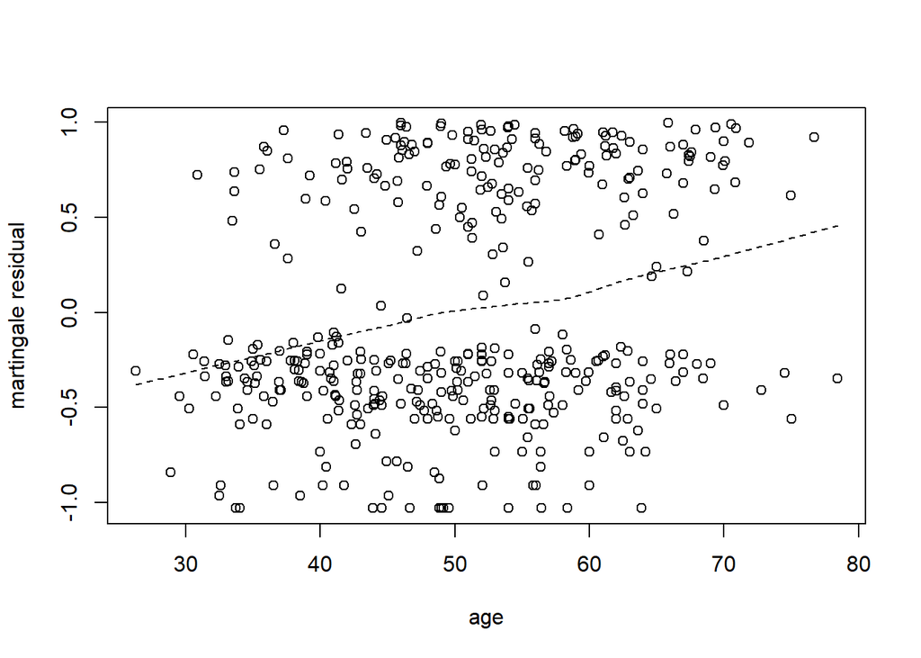

```r
r1 <- resid(fit0,data=pbc,type="martingale")
plot(age,r1,xlab="age",ylab="martingale residual")
lines(lowess(age,r1,iter=0),lty=2)
```

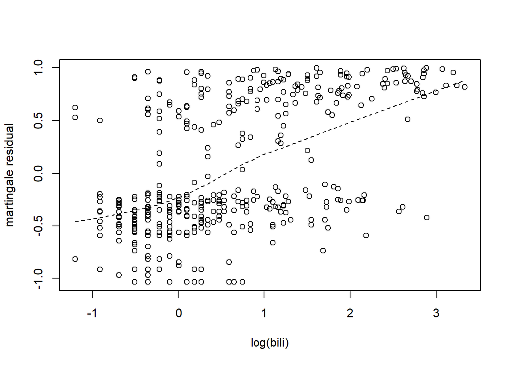

```r
plot(log(bili),r1,xlab="log(bili)",ylab="martingale residual")
lines(lowess(log(bili),r1,iter=0),lty=2)
```

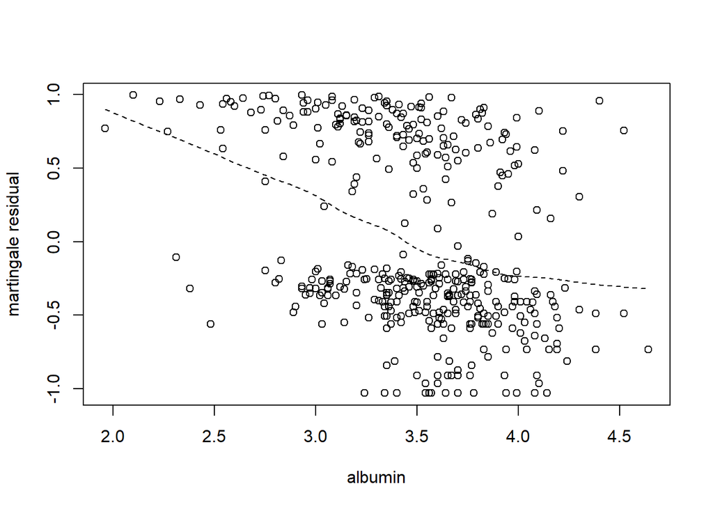

```r
plot(albumin,r1,xlab="albumin",ylab="martingale residual")
lines(lowess(albumin,r1,iter=0),lty=2)
```

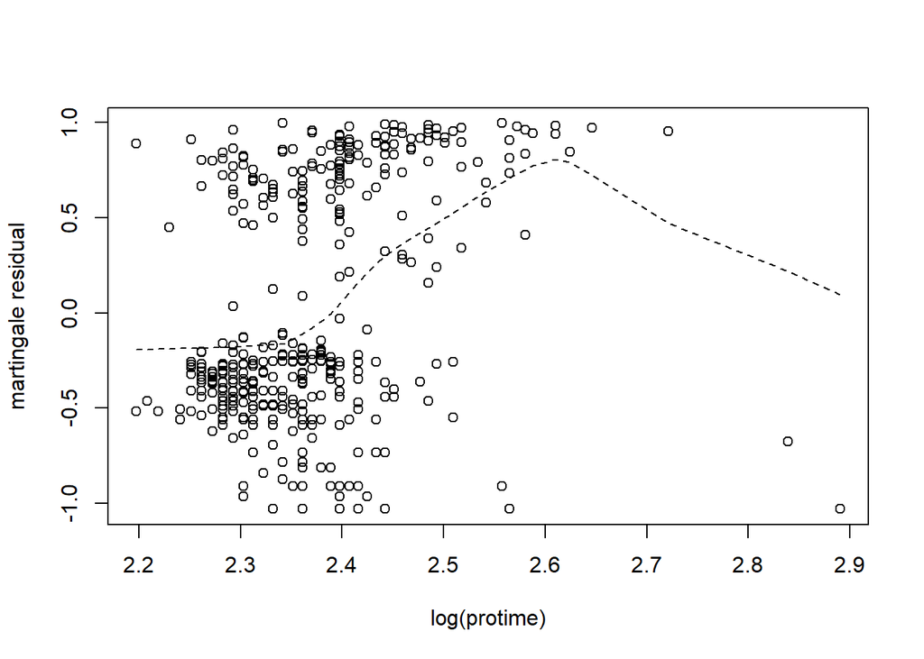

```r
plot(log(protime)[is.na(log(protime))!=TRUE],r1[is.na(log(protime))!=TRUE],xlab="log(protime)",ylab="martingale residual")
lines(lowess(log(protime)[is.na(log(protime))!=TRUE],r1[is.na(log(protime))!=TRUE],iter=0),lty=2)
```

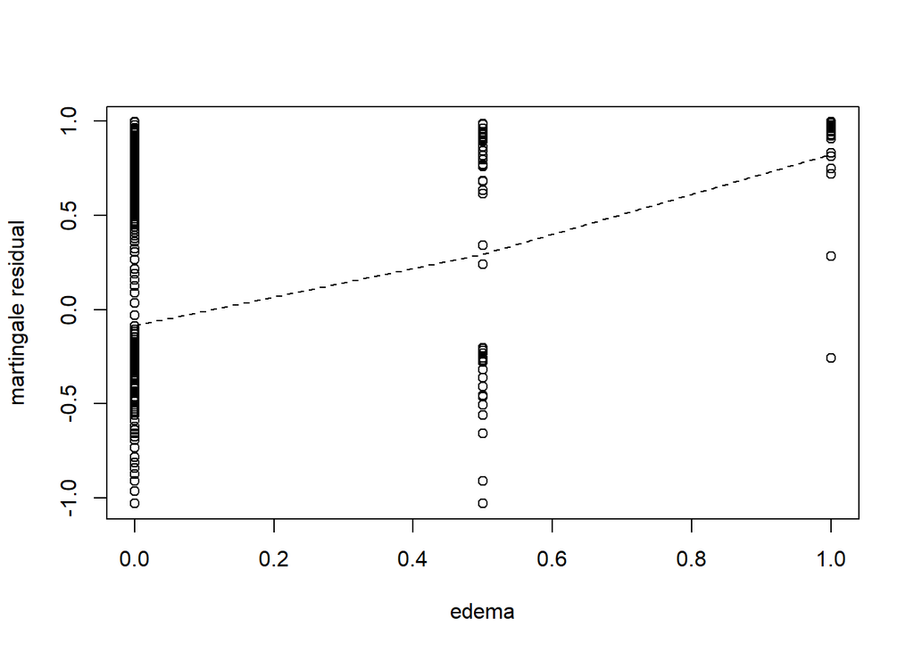

```r
plot(edema,r1,xlab="edema",ylab="martingale residual")
lines(lowess(edema,r1,iter=0),lty=2)
```

### (2) 각각 한 개의 공변량만을 포함한 비례위험모형을 적합한 후 마팅게일 잔차를 구해 잔차그림을 그려보고 공변량이 없는 모형에서의 잔차와 비교해 보시오. 또한 각 모형에 대해 마팅게일 잔차제곱합을 구하시오.

```r
# age
fit1 <- coxph(Surv(time,censor)~age,data=pbc)
summary(fit1)
```

```
## Call:
## coxph(formula = Surv(time, censor) ~ age, data = pbc)
##
##   n= 418, number of events= 161
##
##         coef exp(coef) se(coef)     z Pr(>|z|)
## age 0.039185  1.039963 0.007847 4.994 5.92e-07 ***
## ---
## Signif. codes:  0 '***' 0.001 '**' 0.01 '*' 0.05 '.' 0.1 ' ' 1
##
##     exp(coef) exp(-coef) lower .95 upper .95
## age      1.04     0.9616     1.024     1.056
##
## Concordance= 0.616  (se = 0.023 )
## Likelihood ratio test= 25.19  on 1 df,   p=5e-07
## Wald test            = 24.94  on 1 df,   p=6e-07
## Score (logrank) test = 25.3  on 1 df,   p=5e-07
```

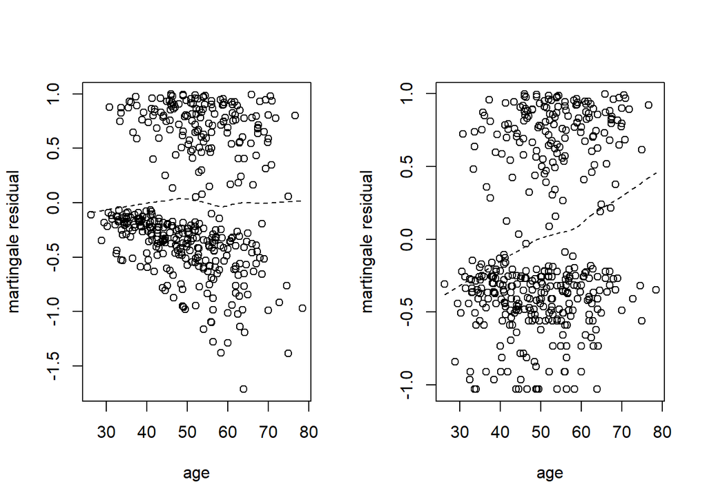

```r
r11 <- resid(fit1,data=pbc,type="martingale")
par(mfrow=c(1,2))
plot(age,r11,xlab="age",ylab="martingale residual")
lines(lowess(age,r11,iter=0),lty=2)
plot(age,r1,xlab="age",ylab="martingale residual")
lines(lowess(age,r1,iter=0),lty=2)
```

```r
par(mfrow=c(1,1))
sum(r11^2) # 160.4154
```

```
## [1] 160.4154
```

#### 변수 age를 포함한 Cox 모형 적합 후 패턴변화가 줄어듬.

```r
# log(bili)
fit2 <- coxph(Surv(time,censor)~log(bili),data=pbc)
summary(fit2)
```

```
## Call:
## coxph(formula = Surv(time, censor) ~ log(bili), data = pbc)
##
##   n= 418, number of events= 161
##
##              coef exp(coef) se(coef)     z Pr(>|z|)
## log(bili) 0.98908   2.68877  0.07836 12.62   <2e-16 ***
## ---
## Signif. codes:  0 '***' 0.001 '**' 0.01 '*' 0.05 '.' 0.1 ' ' 1
##
##           exp(coef) exp(-coef) lower .95 upper .95
## log(bili)     2.689     0.3719     2.306     3.135
##
## Concordance= 0.783  (se = 0.018 )
## Likelihood ratio test= 153.1  on 1 df,   p=<2e-16
## Wald test            = 159.3  on 1 df,   p=<2e-16
## Score (logrank) test = 185.5  on 1 df,   p=<2e-16
```

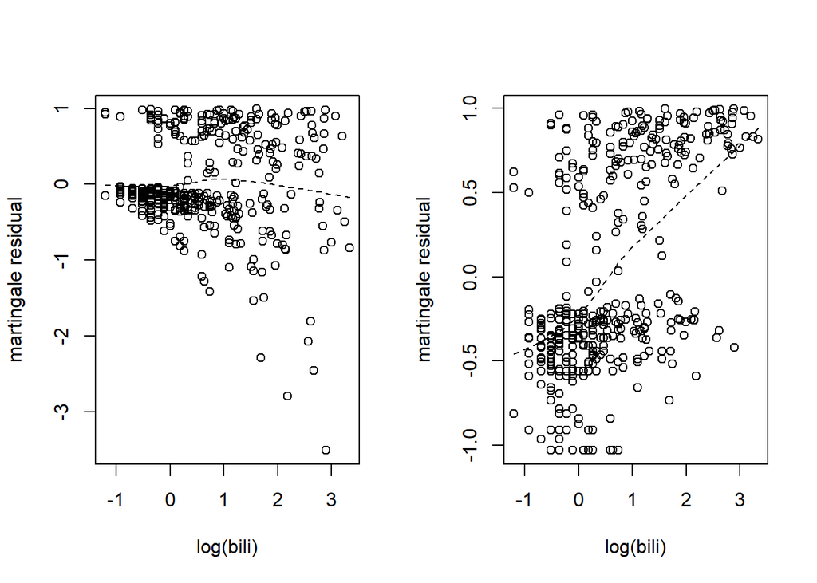

```r
r12 <- resid(fit2,data=pbc,type="martingale")
par(mfrow=c(1,2))
plot(log(bili),r12,xlab="log(bili)",ylab="martingale residual")
lines(lowess(log(bili),r12,iter=0),lty=2)
plot(log(bili),r1,xlab="log(bili)",ylab="martingale residual")
lines(lowess(log(bili),r1,iter=0),lty=2)
```

```r
par(mfrow=c(1,1))
sum(r12^2) # 167.0783
```

```
## [1] 167.0783
```

#### 변수 log(bili)를 포함한 Cox 모형 적합 후 패턴변화가 줄어듬.

```r
# albumin
fit3<- coxph(Surv(time,censor)~albumin,data=pbc)
summary(fit3)
```

```
## Call:
## coxph(formula = Surv(time, censor) ~ albumin, data = pbc)
##
##   n= 418, number of events= 161
##
##            coef exp(coef) se(coef)     z Pr(>|z|)
## albumin -1.5447    0.2134   0.1826 -8.46   <2e-16 ***
## ---
## Signif. codes:  0 '***' 0.001 '**' 0.01 '*' 0.05 '.' 0.1 ' ' 1
##
##         exp(coef) exp(-coef) lower .95 upper .95
## albumin    0.2134      4.687    0.1492    0.3052
##
## Concordance= 0.698  (se = 0.023 )
## Likelihood ratio test= 64.5  on 1 df,   p=1e-15
## Wald test            = 71.57  on 1 df,   p=<2e-16
## Score (logrank) test = 70.46  on 1 df,   p=<2e-16
```

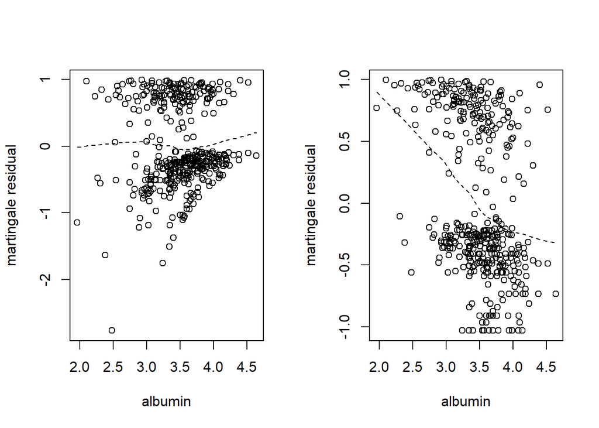

```r
r13 <- resid(fit3,data=pbc,type="martingale")
par(mfrow=c(1,2))
plot(albumin,r13,xlab="albumin",ylab="martingale residual")
lines(lowess(albumin,r13,iter=0),lty=2)
plot(albumin,r1,xlab="albumin",ylab="martingale residual")
lines(lowess(albumin,r1,iter=0),lty=2)
```

```r
par(mfrow=c(1,1))
sum(r13^2) # 167.2901
```

```
## [1] 167.2901
```

#### 변수 albumin을 포함한 Cox 모형 적합 후 패턴변화가 줄어듬.

```r
# log(protime)
fit4<- coxph(Surv(time,censor)~log(protime),data=pbc)
summary(fit4)
```

```
## Call:
## coxph(formula = Surv(time, censor) ~ log(protime), data = pbc)
##
##   n= 416, number of events= 160
##    (2 observations deleted due to missingness)
##
##                 coef exp(coef) se(coef)     z Pr(>|z|)
## log(protime)  3.7997   44.6885   0.5689 6.679  2.4e-11 ***
## ---
## Signif. codes:  0 '***' 0.001 '**' 0.01 '*' 0.05 '.' 0.1 ' ' 1
##
##              exp(coef) exp(-coef) lower .95 upper .95
## log(protime)     44.69    0.02238     14.65     136.3
##
## Concordance= 0.709  (se = 0.024 )
## Likelihood ratio test= 32.59  on 1 df,   p=1e-08
## Wald test            = 44.61  on 1 df,   p=2e-11
## Score (logrank) test = 45.77  on 1 df,   p=1e-11
```

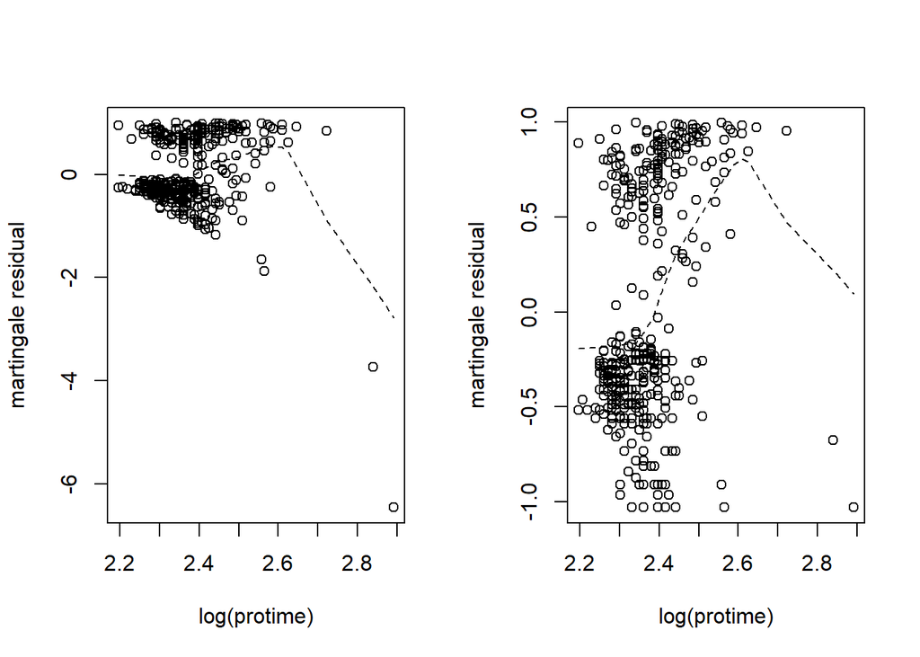

```r
r14 <- resid(fit4,data=pbc,type="martingale")
par(mfrow=c(1,2))
plot(log(protime)[is.na(log(protime))!=TRUE],r14,xlab="log(protime)",ylab="martingale residual")
lines(lowess(log(protime)[is.na(log(protime))!=TRUE],r14,iter=0),lty=2)
plot(log(protime)[is.na(log(protime))!=TRUE],r1[is.na(log(protime))!=TRUE],xlab="log(protime)",ylab="martingale residual")
lines(lowess(log(protime)[is.na(log(protime))!=TRUE],r1[is.na(log(protime))!=TRUE],iter=0),lty=2)
```

```r
par(mfrow=c(1,1))
sum(r14^2) # 201.6861
```

```
## [1] 201.6861
```

#### 변수 log(protime)을 포함한 Cox 모형 적합 후 패턴변화가 줄어듬.

```r
# edema
fit5<- coxph(Surv(time,censor)~edema,data=pbc)
summary(fit5)
```

```
## Call:
## coxph(formula = Surv(time, censor) ~ edema, data = pbc)
##
##   n= 418, number of events= 161
##
##         coef exp(coef) se(coef)     z Pr(>|z|)
## edema 2.2215    9.2214   0.2409 9.221   <2e-16 ***
## ---
## Signif. codes:  0 '***' 0.001 '**' 0.01 '*' 0.05 '.' 0.1 ' ' 1
##
##       exp(coef) exp(-coef) lower .95 upper .95
## edema     9.221     0.1084     5.751     14.79
##
## Concordance= 0.626  (se = 0.02 )
## Likelihood ratio test= 61.08  on 1 df,   p=5e-15
## Wald test            = 85.03  on 1 df,   p=<2e-16
## Score (logrank) test = 102.1  on 1 df,   p=<2e-16
```

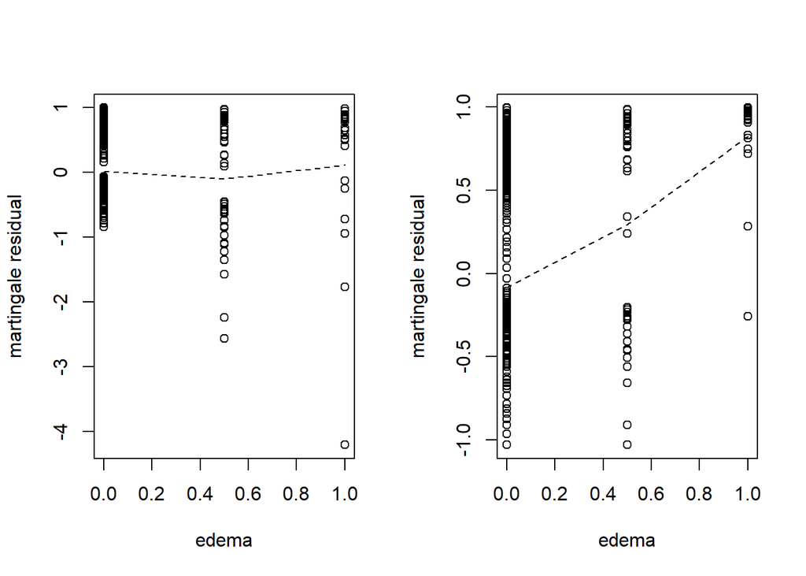

```r
r15 <- resid(fit5,data=pbc,type="martingale")
par(mfrow=c(1,2))
plot(edema,r15,xlab="edema",ylab="martingale residual")
lines(lowess(edema,r15,iter=0),lty=2)
plot(edema,r1,xlab="edema",ylab="martingale residual")
lines(lowess(edema,r1,iter=0),lty=2)
```

```r
par(mfrow=c(1,1))
sum(r15^2) # 178.5449
```

```
## [1] 178.5449
```

#### 변수 edema를 포함한 Cox 모형 적합 후 패턴변화가 줄어듬.

### (3) 공변량이 2개인 비례위험모형을 적합하고 마팅게일 잔차를 구해 잔차그림을 비교해 보시오.

```r
# age, log(bili)
fit <- coxph(Surv(time,censor)~age+log(bili),data=pbc)
summary(fit)
```

```
## Call:
## coxph(formula = Surv(time, censor) ~ age + log(bili), data = pbc)
##
##   n= 418, number of events= 161
##
##               coef exp(coef) se(coef)      z Pr(>|z|)
## age       0.043777  1.044750 0.007504  5.834 5.42e-09 ***
## log(bili) 1.014976  2.759298 0.077961 13.019  < 2e-16 ***
## ---
## Signif. codes:  0 '***' 0.001 '**' 0.01 '*' 0.05 '.' 0.1 ' ' 1
##
##           exp(coef) exp(-coef) lower .95 upper .95
## age           1.045     0.9572     1.029     1.060
## log(bili)     2.759     0.3624     2.368     3.215
##
## Concordance= 0.815  (se = 0.017 )
## Likelihood ratio test= 186.6  on 2 df,   p=<2e-16
## Wald test            = 195.6  on 2 df,   p=<2e-16
## Score (logrank) test = 223.3  on 2 df,   p=<2e-16
```

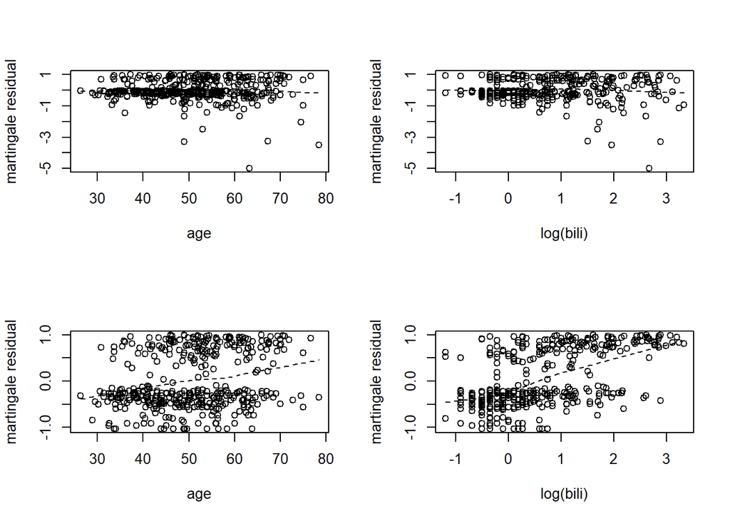

```r
r <- resid(fit,data=pbc,type="martingale")
par(mfrow=c(2,2))
plot(age,r,xlab="age",ylab="martingale residual")
lines(lowess(age,r,iter=0),lty=2)
plot(log(bili),r,xlab="log(bili)",ylab="martingale residual")
lines(lowess(log(bili),r,iter=0),lty=2)
plot(age,r1,xlab="age",ylab="martingale residual")
lines(lowess(age,r1,iter=0),lty=2)
plot(log(bili),r1,xlab="log(bili)",ylab="martingale residual")
lines(lowess(log(bili),r1,iter=0),lty=2)
```

```r
par(mfrow=c(1,1))
```

#### 변수 age, log(bili)를 포함한 Cox 모형 적합 후 패턴변화가 줄어듬.

```r
# age, albumin
fit <- coxph(Surv(time,censor)~age+albumin,data=pbc)
summary(fit)
```

```
## Call:
## coxph(formula = Surv(time, censor) ~ age + albumin, data = pbc)
##
##   n= 418, number of events= 161
##
##              coef exp(coef)  se(coef)      z Pr(>|z|)
## age      0.032664  1.033204  0.008014  4.076 4.58e-05 ***
## albumin -1.428794  0.239598  0.182547 -7.827 5.00e-15 ***
## ---
## Signif. codes:  0 '***' 0.001 '**' 0.01 '*' 0.05 '.' 0.1 ' ' 1
##
##         exp(coef) exp(-coef) lower .95 upper .95
## age        1.0332     0.9679    1.0171    1.0496
## albumin    0.2396     4.1737    0.1675    0.3427
##
## Concordance= 0.721  (se = 0.021 )
## Likelihood ratio test= 81.15  on 2 df,   p=<2e-16
## Wald test            = 87.87  on 2 df,   p=<2e-16
## Score (logrank) test = 88.64  on 2 df,   p=<2e-16
```

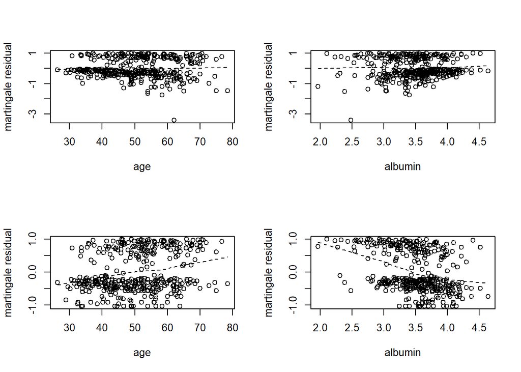

```r
r <- resid(fit,data=pbc,type="martingale")
par(mfrow=c(2,2))
plot(age,r,xlab="age",ylab="martingale residual")
lines(lowess(age,r,iter=0),lty=2)
plot(albumin,r,xlab="albumin",ylab="martingale residual")
lines(lowess(albumin,r,iter=0),lty=2)
plot(age,r1,xlab="age",ylab="martingale residual")
lines(lowess(age,r1,iter=0),lty=2)
plot(albumin,r1,xlab="albumin",ylab="martingale residual")
lines(lowess(albumin,r1,iter=0),lty=2)
```

```r
par(mfrow=c(1,1))
```

#### 변수 age, albumin을 포함한 Cox 모형 적합 후 패턴변화가 줄어듬.

```r
# age, log(protime)
fit <- coxph(Surv(time,censor)~age+log(protime),data=pbc)
summary(fit)
```

```
## Call:
## coxph(formula = Surv(time, censor) ~ age + log(protime), data = pbc)
##
##   n= 416, number of events= 160
##    (2 observations deleted due to missingness)
##
##                  coef exp(coef) se(coef)     z Pr(>|z|)
## age           0.03761   1.03833  0.00768 4.897 9.72e-07 ***
## log(protime)  3.88156  48.49980  0.59227 6.554 5.61e-11 ***
## ---
## Signif. codes:  0 '***' 0.001 '**' 0.01 '*' 0.05 '.' 0.1 ' ' 1
##
##              exp(coef) exp(-coef) lower .95 upper .95
## age              1.038    0.96309     1.023     1.054
## log(protime)    48.500    0.02062    15.192   154.838
##
## Concordance= 0.715  (se = 0.022 )
## Likelihood ratio test= 56.93  on 2 df,   p=4e-13
## Wald test            = 67.19  on 2 df,   p=3e-15
## Score (logrank) test = 68.43  on 2 df,   p=1e-15
```

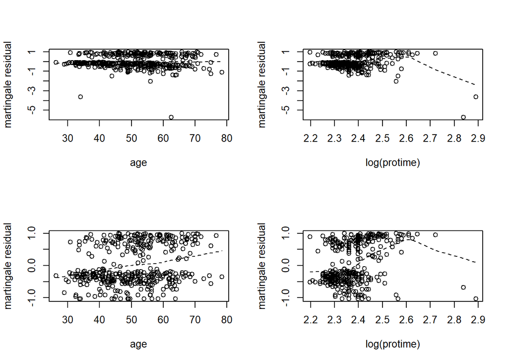

```r
r <- resid(fit,data=pbc,type="martingale")
par(mfrow=c(2,2))
plot(age[is.na(log(protime))!=TRUE],r,xlab="age",ylab="martingale residual")
lines(lowess(age[is.na(log(protime))!=TRUE],r,iter=0),lty=2)
plot(log(protime)[is.na(log(protime))!=TRUE],r,xlab="log(protime)",ylab="martingale residual")
lines(lowess(log(protime)[is.na(log(protime))!=TRUE],r,iter=0),lty=2)
plot(age[is.na(log(protime))!=TRUE],r1[is.na(log(protime))!=TRUE],xlab="age",ylab="martingale residual")
lines(lowess(age[is.na(log(protime))!=TRUE],r1[is.na(log(protime))!=TRUE],iter=0),lty=2)
plot(log(protime)[is.na(log(protime))!=TRUE],r1[is.na(log(protime))!=TRUE],xlab="log(protime)",ylab="martingale residual")
lines(lowess(log(protime)[is.na(log(protime))!=TRUE],r1[is.na(log(protime))!=TRUE],iter=0),lty=2)
```

```r
par(mfrow=c(1,1))
```

#### 변수 age, log(protime)을 포함한 Cox 모형 적합 후 패턴변화가 줄어듬.

```r
# age, edema
fit <- coxph(Surv(time,censor)~age+edema,data=pbc)
summary(fit)
```

```
## Call:
## coxph(formula = Surv(time, censor) ~ age + edema, data = pbc)
##
##   n= 418, number of events= 161
##
##           coef exp(coef) se(coef)     z Pr(>|z|)
## age   0.031607  1.032112 0.007485 4.223 2.41e-05 ***
## edema 2.144844  8.540706 0.252135 8.507  < 2e-16 ***
## ---
## Signif. codes:  0 '***' 0.001 '**' 0.01 '*' 0.05 '.' 0.1 ' ' 1
##
##       exp(coef) exp(-coef) lower .95 upper .95
## age       1.032     0.9689     1.017     1.047
## edema     8.541     0.1171     5.210    13.999
##
## Concordance= 0.682  (se = 0.024 )
## Likelihood ratio test= 78.98  on 2 df,   p=<2e-16
## Wald test            = 98.73  on 2 df,   p=<2e-16
## Score (logrank) test = 117.9  on 2 df,   p=<2e-16
```

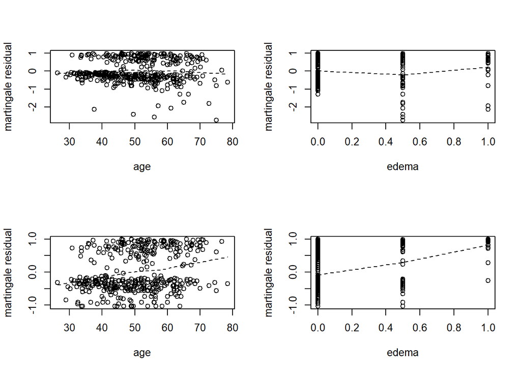

```r
r <- resid(fit,data=pbc,type="martingale")
par(mfrow=c(2,2))
plot(age,r,xlab="age",ylab="martingale residual")
lines(lowess(age,r,iter=0),lty=2)
plot(edema,r,xlab="edema",ylab="martingale residual")
lines(lowess(edema,r,iter=0),lty=2)
plot(age,r1,xlab="age",ylab="martingale residual")
lines(lowess(age,r1,iter=0),lty=2)
plot(edema,r1,xlab="edema",ylab="martingale residual")
lines(lowess(edema,r1,iter=0),lty=2)
```

```r
par(mfrow=c(1,1))
```

#### 변수 age, edema를 포함한 Cox 모형 적합 후 패턴변화가 줄어듬.

```r
# log(bili), albumin
fit <- coxph(Surv(time,censor)~log(bili)+albumin,data=pbc)
summary(fit)
```

```
## Call:
## coxph(formula = Surv(time, censor) ~ log(bili) + albumin, data = pbc)
##
##   n= 418, number of events= 161
##
##               coef exp(coef) se(coef)      z Pr(>|z|)
## log(bili)  0.89394   2.44475  0.08075 11.071  < 2e-16 ***
## albumin   -1.09951   0.33303  0.19782 -5.558 2.73e-08 ***
## ---
## Signif. codes:  0 '***' 0.001 '**' 0.01 '*' 0.05 '.' 0.1 ' ' 1
##
##           exp(coef) exp(-coef) lower .95 upper .95
## log(bili)     2.445      0.409     2.087    2.8640
## albumin       0.333      3.003     0.226    0.4908
##
## Concordance= 0.8  (se = 0.018 )
## Likelihood ratio test= 182.9  on 2 df,   p=<2e-16
## Wald test            = 186.8  on 2 df,   p=<2e-16
## Score (logrank) test = 216.1  on 2 df,   p=<2e-16
```

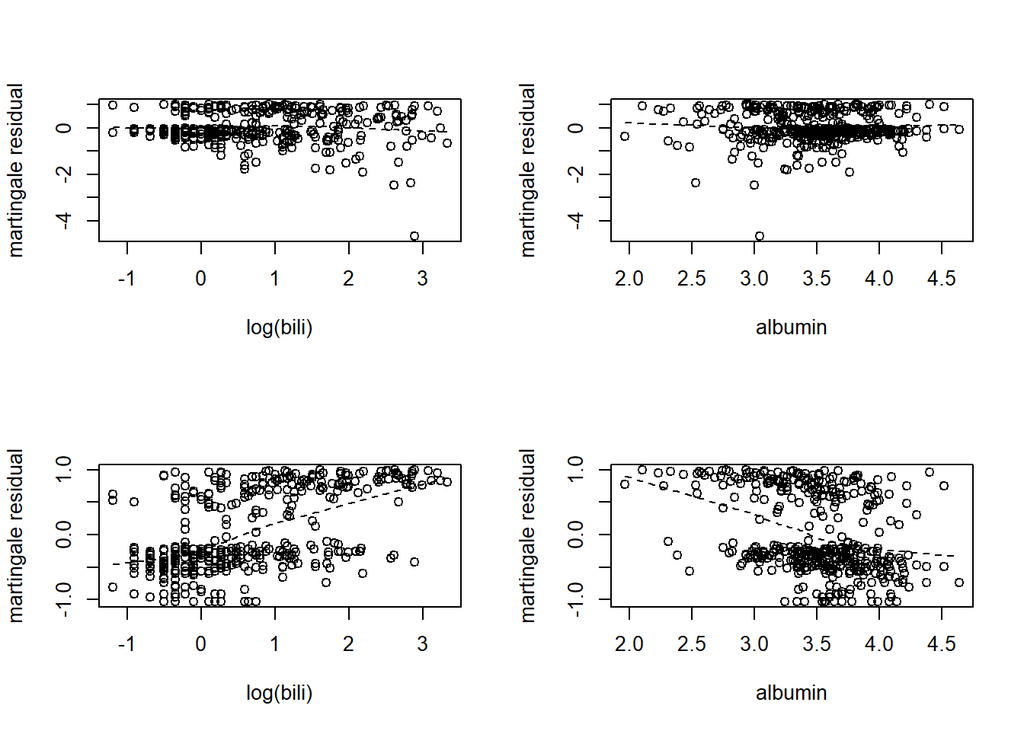

```r
r <- resid(fit,data=pbc,type="martingale")
par(mfrow=c(2,2))
plot(log(bili),r,xlab="log(bili)",ylab="martingale residual")
lines(lowess(log(bili),r,iter=0),lty=2)
plot(albumin,r,xlab="albumin",ylab="martingale residual")
lines(lowess(albumin,r,iter=0),lty=2)
plot(log(bili),r1,xlab="log(bili)",ylab="martingale residual")
lines(lowess(log(bili),r1,iter=0),lty=2)
plot(albumin,r1,xlab="albumin",ylab="martingale residual")
lines(lowess(albumin,r1,iter=0),lty=2)
```

```r
par(mfrow=c(1,1))
```

#### 변수 log(bili), albumin을 포함한 Cox 모형 적합 후 패턴변화가 줄어듬.

```r
# log(bili), log(protime)
fit <- coxph(Surv(time,censor)~log(bili)+log(protime),data=pbc)
summary(fit)
```

```
## Call:
## coxph(formula = Surv(time, censor) ~ log(bili) + log(protime),
##     data = pbc)
##
##   n= 416, number of events= 160
##    (2 observations deleted due to missingness)
##
##                  coef exp(coef) se(coef)      z Pr(>|z|)
## log(bili)     0.93059   2.53601  0.07962 11.689  < 2e-16 ***
## log(protime)  2.89057  18.00362  0.65967  4.382 1.18e-05 ***
## ---
## Signif. codes:  0 '***' 0.001 '**' 0.01 '*' 0.05 '.' 0.1 ' ' 1
##
##              exp(coef) exp(-coef) lower .95 upper .95
## log(bili)        2.536    0.39432     2.170     2.964
## log(protime)    18.004    0.05554     4.941    65.595
##
## Concordance= 0.795  (se = 0.018 )
## Likelihood ratio test= 165.4  on 2 df,   p=<2e-16
## Wald test            = 173.8  on 2 df,   p=<2e-16
## Score (logrank) test = 204.6  on 2 df,   p=<2e-16
```

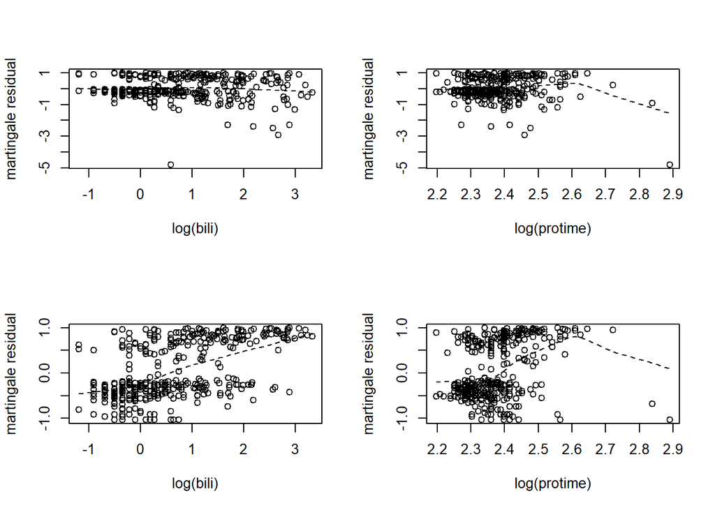

```r
r <- resid(fit,data=pbc,type="martingale")
par(mfrow=c(2,2))
plot(log(bili)[is.na(log(protime))!=TRUE],r,xlab="log(bili)",ylab="martingale residual")
lines(lowess(log(bili)[is.na(log(protime))!=TRUE],r,iter=0),lty=2)
plot(log(protime)[is.na(log(protime))!=TRUE],r,xlab="log(protime)",ylab="martingale residual")
lines(lowess(log(protime)[is.na(log(protime))!=TRUE],r,iter=0),lty=2)
plot(log(bili)[is.na(log(protime))!=TRUE],r1[is.na(log(protime))!=TRUE],xlab="log(bili)",ylab="martingale residual")
lines(lowess(log(bili)[is.na(log(protime))!=TRUE],r1[is.na(log(protime))!=TRUE],iter=0),lty=2)
plot(log(protime)[is.na(log(protime))!=TRUE],r1[is.na(log(protime))!=TRUE],xlab="log(protime)",ylab="martingale residual")
lines(lowess(log(protime)[is.na(log(protime))!=TRUE],r1[is.na(log(protime))!=TRUE],iter=0),lty=2)
```

```r
par(mfrow=c(1,1))
```

#### 변수 log(bili), log(protime)을 포함한 Cox 모형 적합 후 패턴변화가 줄어듬.

```r
# log(bili), edema
fit <- coxph(Surv(time,censor)~log(bili)+edema,data=pbc)
summary(fit)
```

```
## Call:
## coxph(formula = Surv(time, censor) ~ log(bili) + edema, data = pbc)
##
##   n= 418, number of events= 161
##
##              coef exp(coef) se(coef)     z Pr(>|z|)
## log(bili) 0.89547   2.44849  0.08069 11.10  < 2e-16 ***
## edema     1.43450   4.19755  0.24947  5.75 8.91e-09 ***
## ---
## Signif. codes:  0 '***' 0.001 '**' 0.01 '*' 0.05 '.' 0.1 ' ' 1
##
##           exp(coef) exp(-coef) lower .95 upper .95
## log(bili)     2.448     0.4084     2.090     2.868
## edema         4.198     0.2382     2.574     6.845
##
## Concordance= 0.809  (se = 0.017 )
## Likelihood ratio test= 180.6  on 2 df,   p=<2e-16
## Wald test            = 204.6  on 2 df,   p=<2e-16
## Score (logrank) test = 252.5  on 2 df,   p=<2e-16
```

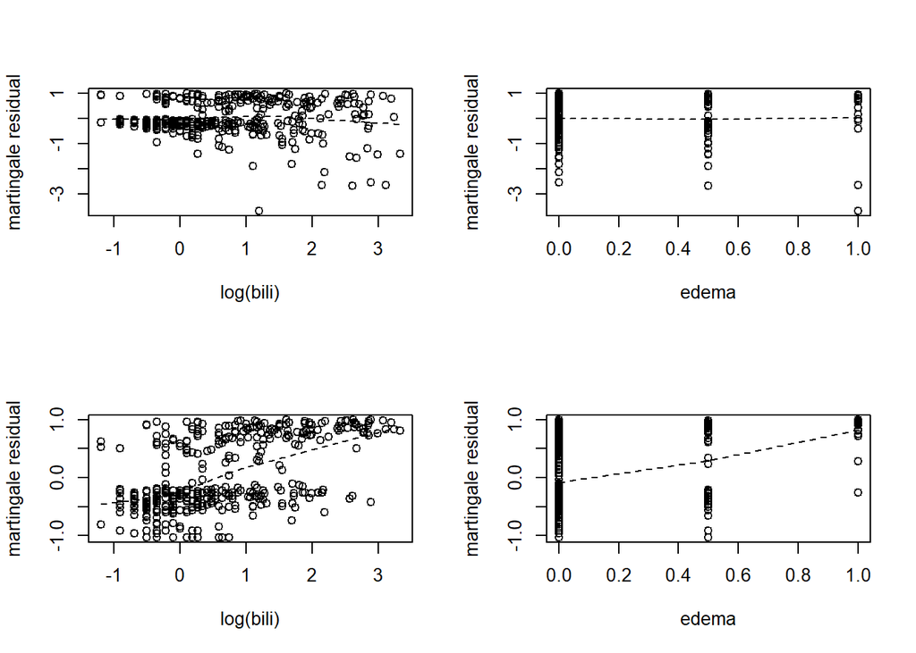

```r
r <- resid(fit,data=pbc,type="martingale")
par(mfrow=c(2,2))
plot(log(bili),r,xlab="log(bili)",ylab="martingale residual")
lines(lowess(log(bili),r,iter=0),lty=2)
plot(edema,r,xlab="edema",ylab="martingale residual")
lines(lowess(edema,r,iter=0),lty=2)
plot(log(bili),r1,xlab="log(bili)",ylab="martingale residual")
lines(lowess(log(bili),r1,iter=0),lty=2)
plot(edema,r1,xlab="edema",ylab="martingale residual")
lines(lowess(edema,r1,iter=0),lty=2)
```

```r
par(mfrow=c(1,1))
```

#### 변수 log(bili), edema를 포함한 Cox 모형 적합 후 패턴변화가 줄어듬.

```r
# albumin, log(protime)
fit <- coxph(Surv(time,censor)~albumin+log(protime),data=pbc)
summary(fit)
```

```
## Call:
## coxph(formula = Surv(time, censor) ~ albumin + log(protime),
##     data = pbc)
##
##   n= 416, number of events= 160
##    (2 observations deleted due to missingness)
##
##                 coef exp(coef) se(coef)      z Pr(>|z|)
## albumin      -1.4377    0.2375   0.1875 -7.667 1.77e-14 ***
## log(protime)  3.1576   23.5152   0.5900  5.352 8.71e-08 ***
## ---
## Signif. codes:  0 '***' 0.001 '**' 0.01 '*' 0.05 '.' 0.1 ' ' 1
##
##              exp(coef) exp(-coef) lower .95 upper .95
## albumin         0.2375    4.21090    0.1644     0.343
## log(protime)   23.5152    0.04253    7.3980    74.745
##
## Concordance= 0.742  (se = 0.022 )
## Likelihood ratio test= 86.75  on 2 df,   p=<2e-16
## Wald test            = 101.5  on 2 df,   p=<2e-16
## Score (logrank) test = 106.2  on 2 df,   p=<2e-16
```

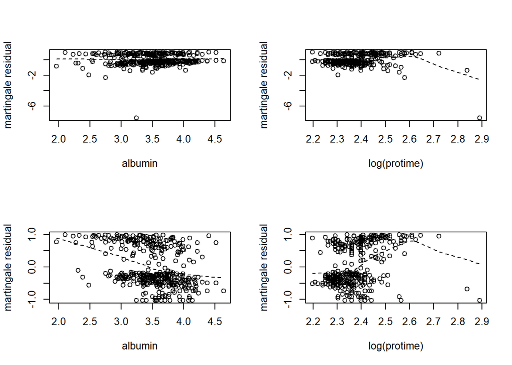

```r
r <- resid(fit,data=pbc,type="martingale")
par(mfrow=c(2,2))
plot(albumin[is.na(log(protime))!=TRUE],r,xlab="albumin",ylab="martingale residual")
lines(lowess(albumin[is.na(log(protime))!=TRUE],r,iter=0),lty=2)
plot(log(protime)[is.na(log(protime))!=TRUE],r,xlab="log(protime)",ylab="martingale residual")
lines(lowess(log(protime)[is.na(log(protime))!=TRUE],r,iter=0),lty=2)
plot(albumin[is.na(log(protime))!=TRUE],r1[is.na(log(protime))!=TRUE],xlab="albumin",ylab="martingale residual")
lines(lowess(albumin[is.na(log(protime))!=TRUE],r1[is.na(log(protime))!=TRUE],iter=0),lty=2)
plot(log(protime)[is.na(log(protime))!=TRUE],r1[is.na(log(protime))!=TRUE],xlab="log(protime)",ylab="martingale residual")
lines(lowess(log(protime)[is.na(log(protime))!=TRUE],r1[is.na(log(protime))!=TRUE],iter=0),lty=2)
```

```r
par(mfrow=c(1,1))
```

#### 변수 albumin, log(protime)을 포함한 Cox 모형 적합 후 패턴변화가 줄어듬.

```r
# albumin, edema
fit <- coxph(Surv(time,censor)~albumin+edema,data=pbc)
summary(fit)
```

```
## Call:
## coxph(formula = Surv(time, censor) ~ albumin + edema, data = pbc)
##
##   n= 418, number of events= 161
##
##            coef exp(coef) se(coef)      z Pr(>|z|)
## albumin -1.2338    0.2912   0.1942 -6.352 2.12e-10 ***
## edema    1.6581    5.2494   0.2580  6.427 1.30e-10 ***
## ---
## Signif. codes:  0 '***' 0.001 '**' 0.01 '*' 0.05 '.' 0.1 ' ' 1
##
##         exp(coef) exp(-coef) lower .95 upper .95
## albumin    0.2912     3.4343     0.199    0.4261
## edema      5.2494     0.1905     3.166    8.7039
##
## Concordance= 0.732  (se = 0.022 )
## Likelihood ratio test= 98.67  on 2 df,   p=<2e-16
## Wald test            = 125.5  on 2 df,   p=<2e-16
## Score (logrank) test = 142.7  on 2 df,   p=<2e-16
```

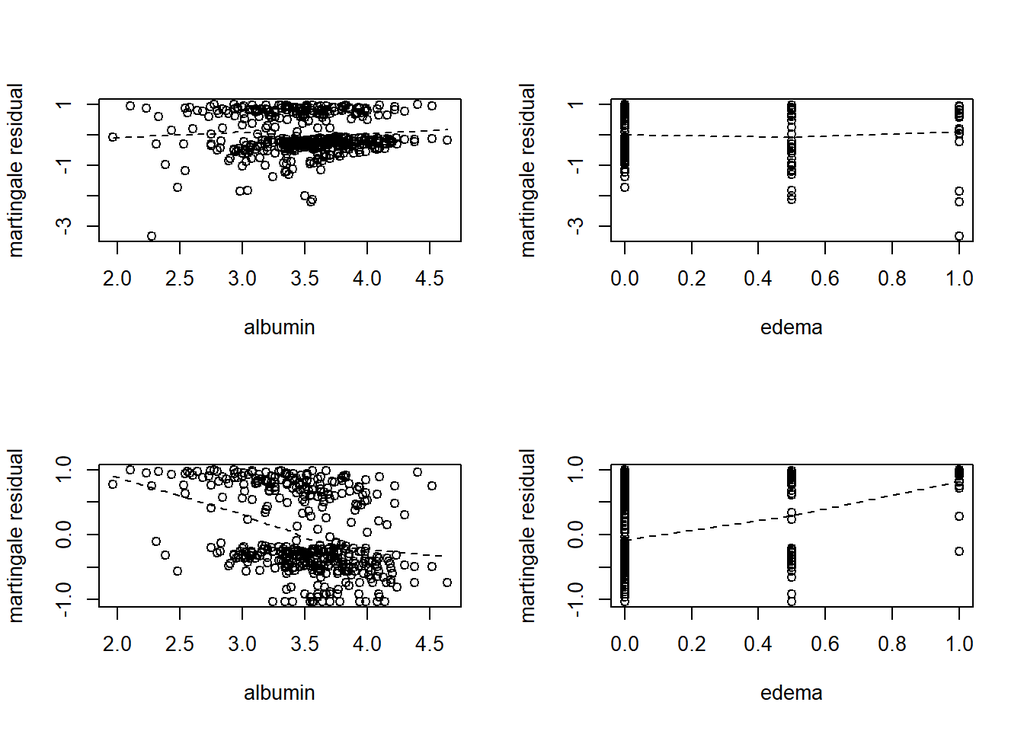

```r
r <- resid(fit,data=pbc,type="martingale")
par(mfrow=c(2,2))
plot(albumin,r,xlab="albumin",ylab="martingale residual")
lines(lowess(albumin,r,iter=0),lty=2)
plot(edema,r,xlab="edema",ylab="martingale residual")
lines(lowess(edema,r,iter=0),lty=2)
plot(albumin,r1,xlab="albumin",ylab="martingale residual")
lines(lowess(albumin,r1,iter=0),lty=2)
plot(edema,r1,xlab="edema",ylab="martingale residual")
lines(lowess(edema,r1,iter=0),lty=2)
```

```r
par(mfrow=c(1,1))
```

#### 변수 albumin, edema를 포함한 Cox 모형 적합 후 패턴변화가 줄어듬.

```r
# log(protime), edema
fit <- coxph(Surv(time,censor)~log(protime)+edema,data=pbc)
summary(fit)
```

```
## Call:
## coxph(formula = Surv(time, censor) ~ log(protime) + edema, data = pbc)
##
##   n= 416, number of events= 160
##    (2 observations deleted due to missingness)
##
##                 coef exp(coef) se(coef)     z Pr(>|z|)
## log(protime)  3.1763   23.9585   0.6628 4.793 1.65e-06 ***
## edema         1.9326    6.9074   0.2473 7.816 5.44e-15 ***
## ---
## Signif. codes:  0 '***' 0.001 '**' 0.01 '*' 0.05 '.' 0.1 ' ' 1
##
##              exp(coef) exp(-coef) lower .95 upper .95
## log(protime)    23.959    0.04174     6.536     87.82
## edema            6.907    0.14477     4.255     11.21
##
## Concordance= 0.731  (se = 0.023 )
## Likelihood ratio test= 79.75  on 2 df,   p=<2e-16
## Wald test            = 106  on 2 df,   p=<2e-16
## Score (logrank) test = 126.6  on 2 df,   p=<2e-16
```

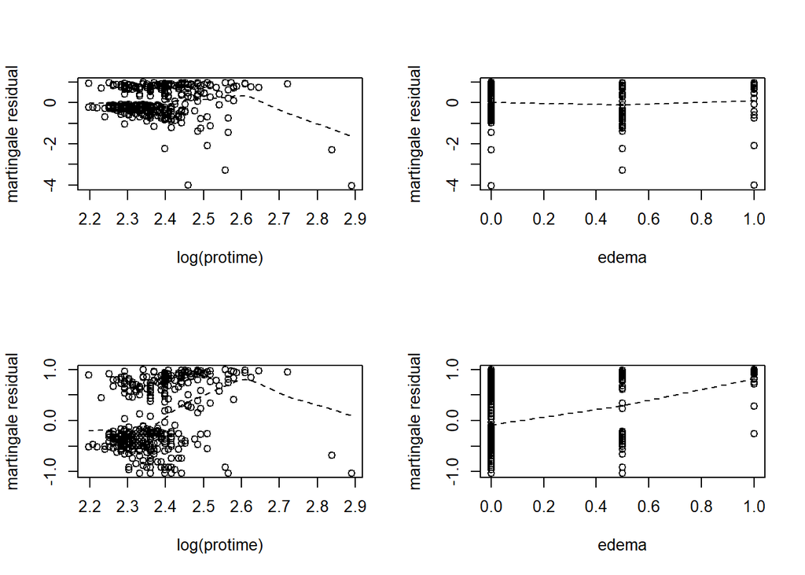

```r
r <- resid(fit,data=pbc,type="martingale")
par(mfrow=c(2,2))
plot(log(protime)[is.na(log(protime))!=TRUE],r,xlab="log(protime)",ylab="martingale residual")
lines(lowess(log(protime)[is.na(log(protime))!=TRUE],r,iter=0),lty=2)
plot(edema[is.na(log(protime))!=TRUE],r,xlab="edema",ylab="martingale residual")
lines(lowess(edema[is.na(log(protime))!=TRUE],r,iter=0),lty=2)
plot(log(protime)[is.na(log(protime))!=TRUE],r1[is.na(log(protime))!=TRUE],xlab="log(protime)",ylab="martingale residual")
lines(lowess(log(protime)[is.na(log(protime))!=TRUE],r1[is.na(log(protime))!=TRUE],iter=0),lty=2)
plot(edema[is.na(log(protime))!=TRUE],r1[is.na(log(protime))!=TRUE],xlab="edema",ylab="martingale residual")
lines(lowess(edema[is.na(log(protime))!=TRUE],r1[is.na(log(protime))!=TRUE],iter=0),lty=2)
```

```r
par(mfrow=c(1,1))
```

#### 변수 log(protime), edema를 포함한 Cox 모형 적합 후 패턴변화가 줄어듬.

### (4) 공변량이 없는 모형에서 편차 잔차를 그리고 잔차그림을 그리시오.

```r
attach(pbc)
Surv(time,censor)
```

[output not shown]

[output cut: 20 more lines]

```r
fit0 <- coxph(Surv(time,censor)~1,data=pbc)
summary(fit0)
```

```
## Call:  coxph(formula = Surv(time, censor) ~ 1, data = pbc)
##
## Null model
##   log likelihood= -873.4721
##   n= 418
```

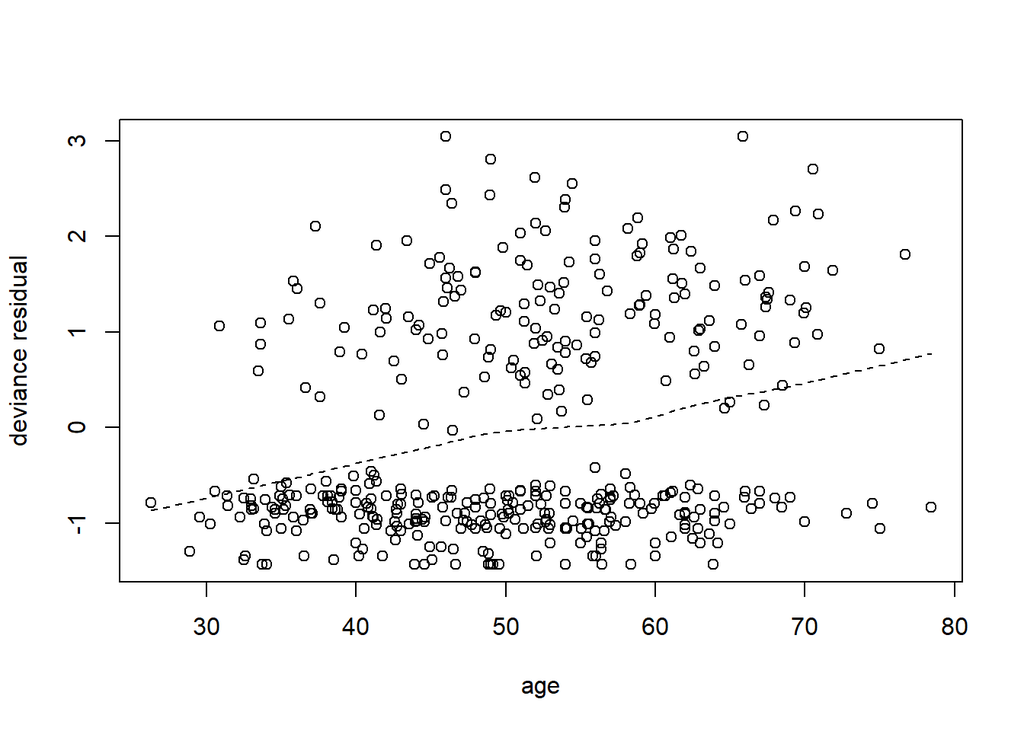

```r
r1 <- resid(fit0,data=pbc,type="deviance")
plot(age,r1,xlab="age",ylab="deviance residual")
lines(lowess(age,r1,iter=0),lty=2)
```

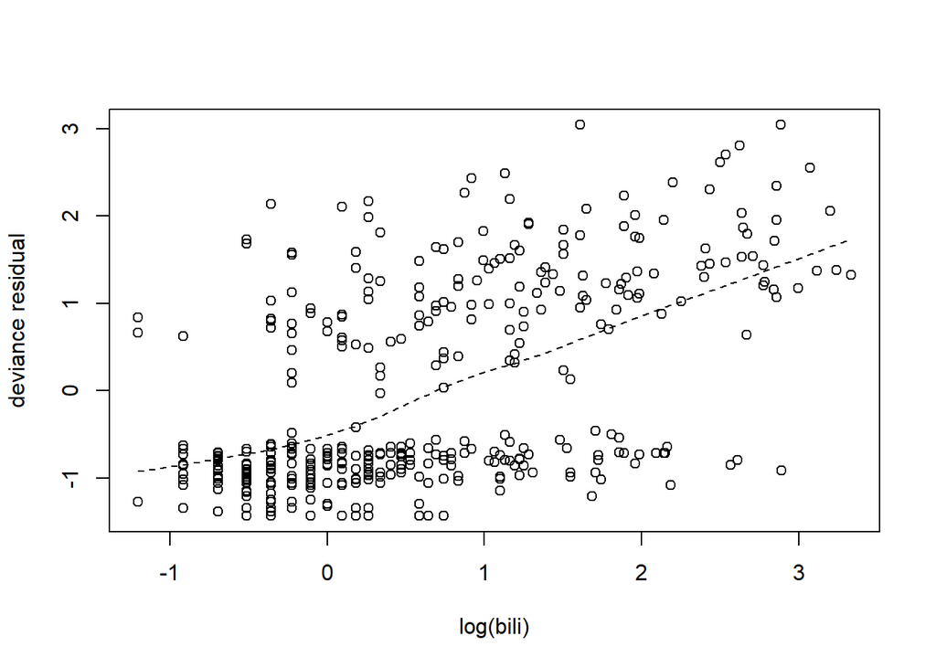

```r
plot(log(bili),r1,xlab="log(bili)",ylab="deviance residual")
lines(lowess(log(bili),r1,iter=0),lty=2)
```

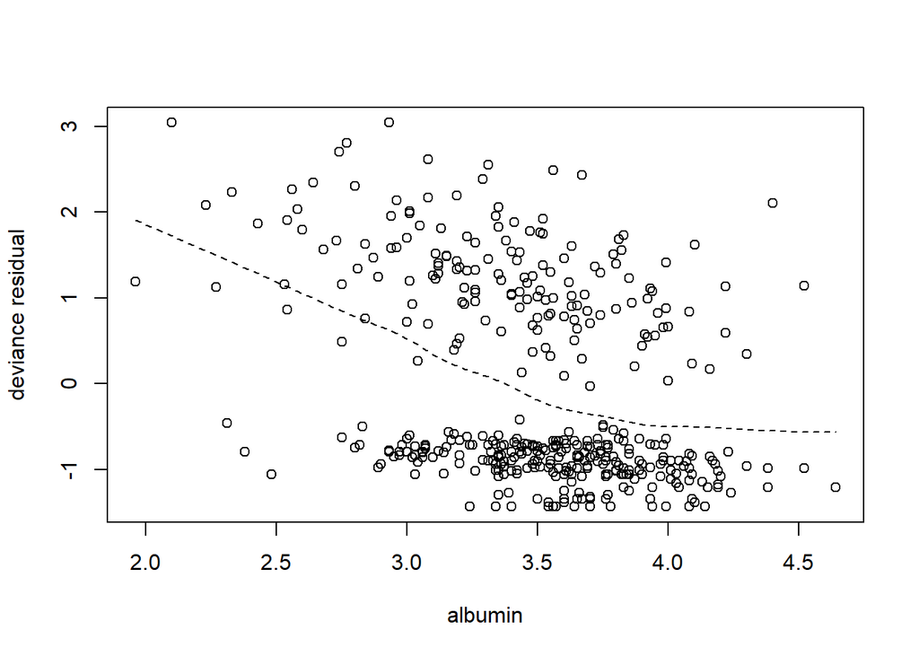

```r
plot(albumin,r1,xlab="albumin",ylab="deviance residual")
lines(lowess(albumin,r1,iter=0),lty=2)
```

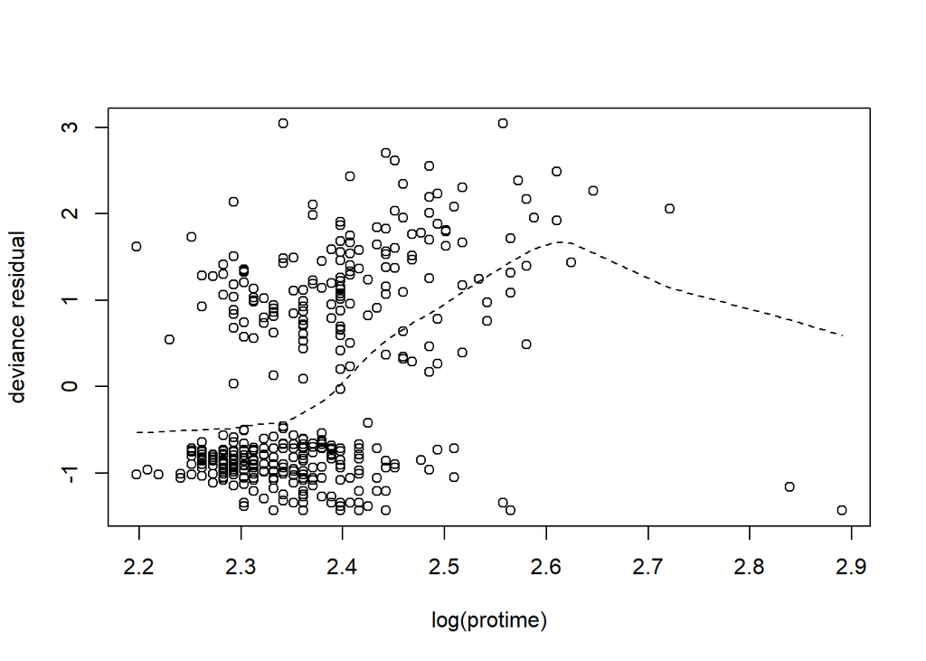

```r
plot(log(protime)[is.na(log(protime))!=TRUE],r1[is.na(log(protime))!=TRUE],xlab="log(protime)",ylab="deviance residual")
lines(lowess(log(protime)[is.na(log(protime))!=TRUE],r1[is.na(log(protime))!=TRUE],iter=0),lty=2)
```

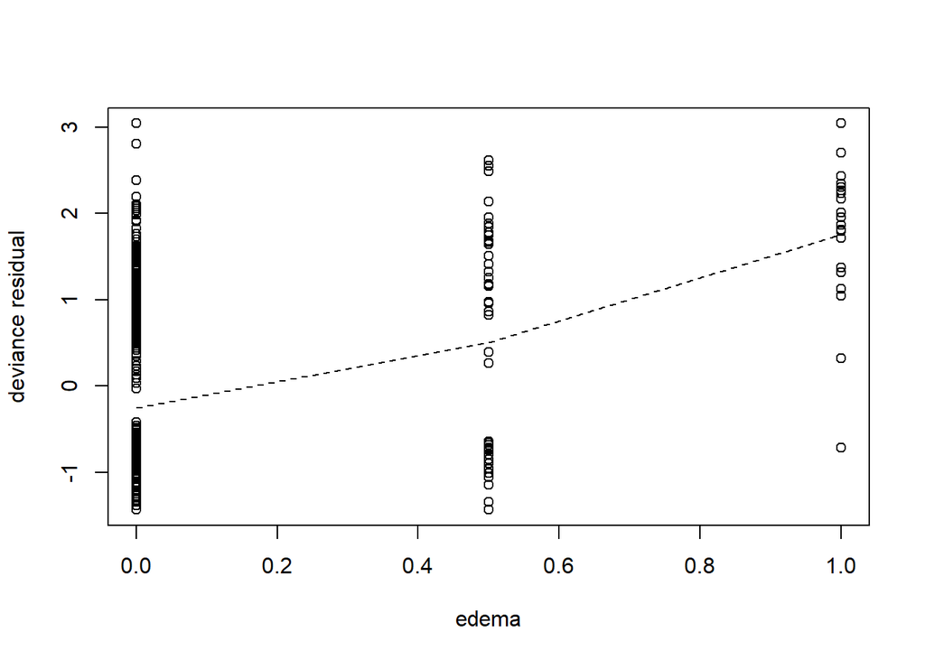

```r
plot(edema,r1,xlab="edema",ylab="deviance residual")
lines(lowess(edema,r1,iter=0),lty=2)
```

### (5) 각각 한 개의 공변량만을 포함한 비례위험모형을 적합한 후 편차 잔차를 구해 잔차그림을 그려보고 공변량이 없는 모형에서의 잔차와 비교해 보시오. 또한 각 모형에 대해 편차 잔차제곱합을 구하시오.

```r
# age
fit1 <- coxph(Surv(time,censor)~age,data=pbc)
summary(fit1)
```

```
## Call:
## coxph(formula = Surv(time, censor) ~ age, data = pbc)
##
##   n= 418, number of events= 161
##
##         coef exp(coef) se(coef)     z Pr(>|z|)
## age 0.039185  1.039963 0.007847 4.994 5.92e-07 ***
## ---
## Signif. codes:  0 '***' 0.001 '**' 0.01 '*' 0.05 '.' 0.1 ' ' 1
##
##     exp(coef) exp(-coef) lower .95 upper .95
## age      1.04     0.9616     1.024     1.056
##
## Concordance= 0.616  (se = 0.023 )
## Likelihood ratio test= 25.19  on 1 df,   p=5e-07
## Wald test            = 24.94  on 1 df,   p=6e-07
## Score (logrank) test = 25.3  on 1 df,   p=5e-07
```

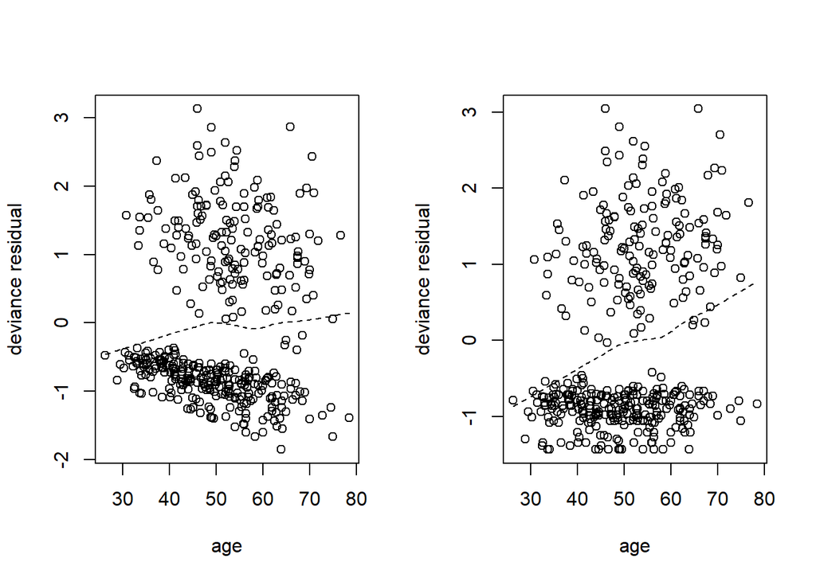

```r
r11 <- resid(fit1,data=pbc,type="deviance")
par(mfrow=c(1,2))
plot(age,r11,xlab="age",ylab="deviance residual")
lines(lowess(age,r11,iter=0),lty=2)
plot(age,r1,xlab="age",ylab="deviance residual")
lines(lowess(age,r1,iter=0),lty=2)
```

```r
par(mfrow=c(1,1))
sum(r11^2) # 536.5112
```

```
## [1] 536.5112
```

#### 변수 age를 포함한 Cox 모형 적합 후 패턴변화가 줄어듬.

```r
# log(bili)
fit2 <- coxph(Surv(time,censor)~log(bili),data=pbc)
summary(fit2)
```

```
## Call:
## coxph(formula = Surv(time, censor) ~ log(bili), data = pbc)
##
##   n= 418, number of events= 161
##
##              coef exp(coef) se(coef)     z Pr(>|z|)
## log(bili) 0.98908   2.68877  0.07836 12.62   <2e-16 ***
## ---
## Signif. codes:  0 '***' 0.001 '**' 0.01 '*' 0.05 '.' 0.1 ' ' 1
##
##           exp(coef) exp(-coef) lower .95 upper .95
## log(bili)     2.689     0.3719     2.306     3.135
##
## Concordance= 0.783  (se = 0.018 )
## Likelihood ratio test= 153.1  on 1 df,   p=<2e-16
## Wald test            = 159.3  on 1 df,   p=<2e-16
## Score (logrank) test = 185.5  on 1 df,   p=<2e-16
```

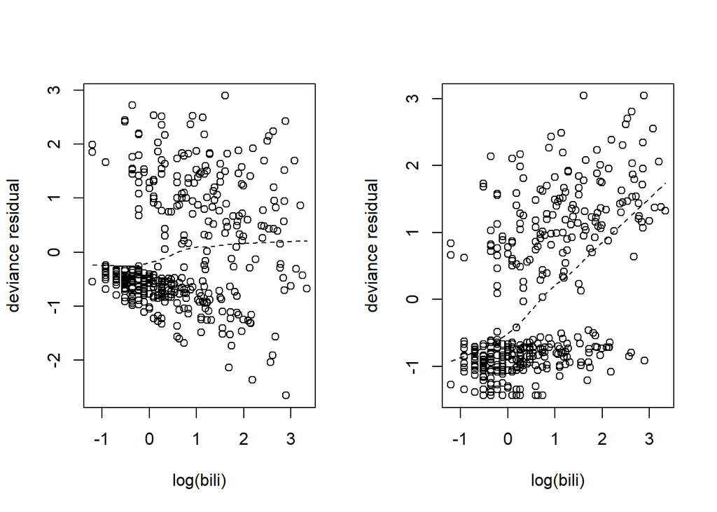

```r
r12 <- resid(fit2,data=pbc,type="deviance")
par(mfrow=c(1,2))
plot(log(bili),r12,xlab="log(bili)",ylab="deviance residual")
lines(lowess(log(bili),r12,iter=0),lty=2)
plot(log(bili),r1,xlab="log(bili)",ylab="deviance residual")
lines(lowess(log(bili),r1,iter=0),lty=2)
```

```r
par(mfrow=c(1,1))
sum(r12^2) # 463.6309
```

```
## [1] 463.6309
```

#### 변수 log(bili)를 포함한 Cox 모형 적합 후 패턴변화가 줄어듬.

```r
# albumin
fit3<- coxph(Surv(time,censor)~albumin,data=pbc)
summary(fit3)
```

```
## Call:
## coxph(formula = Surv(time, censor) ~ albumin, data = pbc)
##
##   n= 418, number of events= 161
##
##            coef exp(coef) se(coef)     z Pr(>|z|)
## albumin -1.5447    0.2134   0.1826 -8.46   <2e-16 ***
## ---
## Signif. codes:  0 '***' 0.001 '**' 0.01 '*' 0.05 '.' 0.1 ' ' 1
##
##         exp(coef) exp(-coef) lower .95 upper .95
## albumin    0.2134      4.687    0.1492    0.3052
##
## Concordance= 0.698  (se = 0.023 )
## Likelihood ratio test= 64.5  on 1 df,   p=1e-15
## Wald test            = 71.57  on 1 df,   p=<2e-16
## Score (logrank) test = 70.46  on 1 df,   p=<2e-16
```

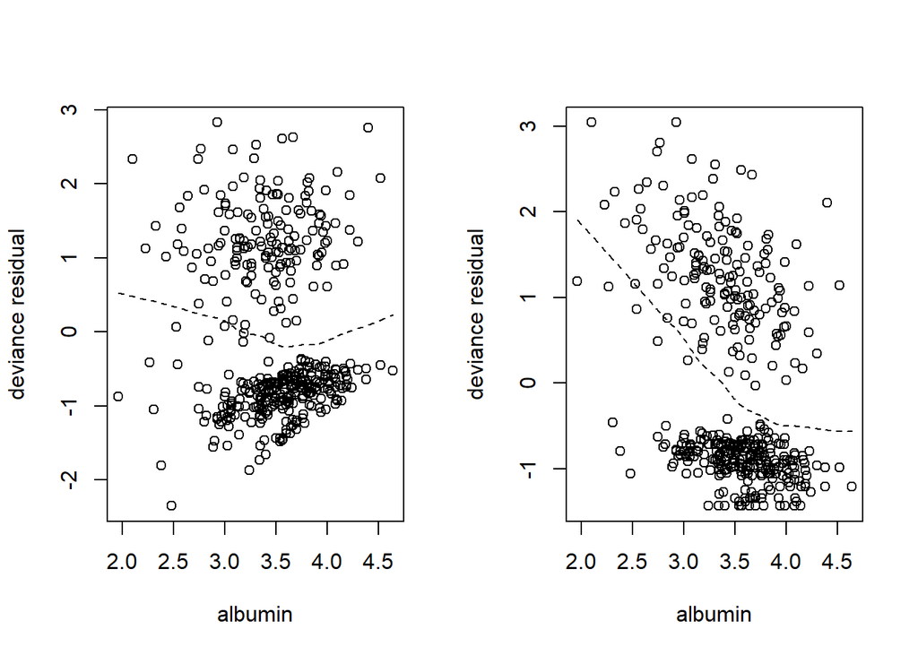

```r
r13 <- resid(fit3,data=pbc,type="deviance")
par(mfrow=c(1,2))
plot(albumin,r13,xlab="albumin",ylab="deviance residual")
lines(lowess(albumin,r13,iter=0),lty=2)
plot(albumin,r1,xlab="albumin",ylab="deviance residual")
lines(lowess(albumin,r1,iter=0),lty=2)
```

```r
par(mfrow=c(1,1))
sum(r13^2) # 523.1606
```

```
## [1] 523.1606
```

#### 변수 albumin을 포함한 Cox 모형 적합 후 패턴변화가 줄어듬.

```r
# log(protime)
fit4<- coxph(Surv(time,censor)~log(protime),data=pbc)
summary(fit4)
```

```
## Call:
## coxph(formula = Surv(time, censor) ~ log(protime), data = pbc)
##
##   n= 416, number of events= 160
##    (2 observations deleted due to missingness)
##
##                 coef exp(coef) se(coef)     z Pr(>|z|)
## log(protime)  3.7997   44.6885   0.5689 6.679  2.4e-11 ***
## ---
## Signif. codes:  0 '***' 0.001 '**' 0.01 '*' 0.05 '.' 0.1 ' ' 1
##
##              exp(coef) exp(-coef) lower .95 upper .95
## log(protime)     44.69    0.02238     14.65     136.3
##
## Concordance= 0.709  (se = 0.024 )
## Likelihood ratio test= 32.59  on 1 df,   p=1e-08
## Wald test            = 44.61  on 1 df,   p=2e-11
## Score (logrank) test = 45.77  on 1 df,   p=1e-11
```

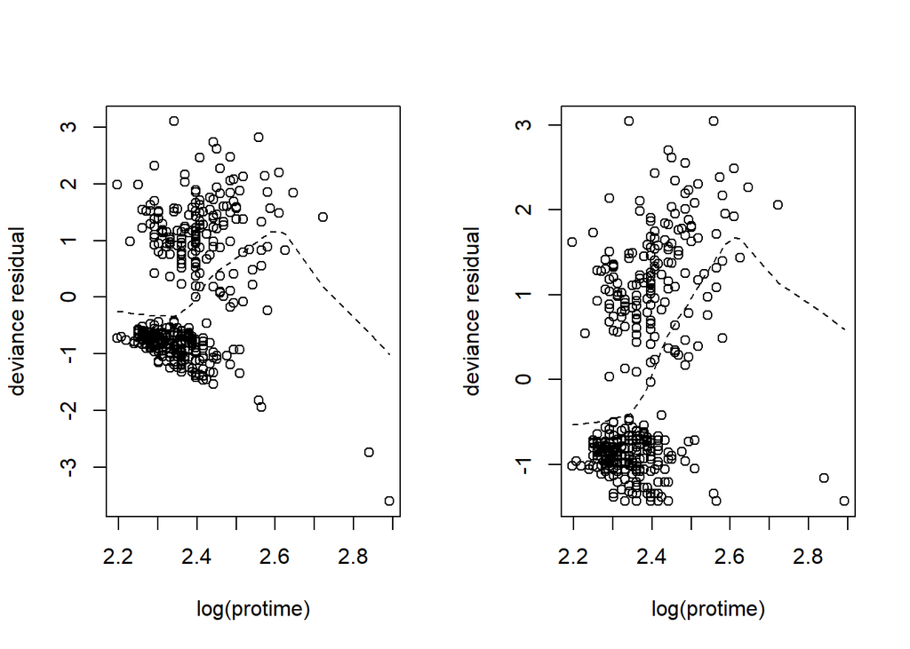

```r
r14 <- resid(fit4,data=pbc,type="deviance")
par(mfrow=c(1,2))
plot(log(protime)[is.na(log(protime))!=TRUE],r14,xlab="log(protime)",ylab="deviance residual")
lines(lowess(log(protime)[is.na(log(protime))!=TRUE],r14,iter=0),lty=2)
plot(log(protime)[is.na(log(protime))!=TRUE],r1[is.na(log(protime))!=TRUE],xlab="log(protime)",ylab="deviance residual")
lines(lowess(log(protime)[is.na(log(protime))!=TRUE],r1[is.na(log(protime))!=TRUE],iter=0),lty=2)
```

```r
par(mfrow=c(1,1))
sum(r14^2) # 514.5766
```

```
## [1] 514.5766
```

#### 변수 log(protime)을 포함한 Cox 모형 적합 후 패턴변화가 줄어듬.

```r
# edema
fit5<- coxph(Surv(time,censor)~edema,data=pbc)
summary(fit5)
```

```
## Call:
## coxph(formula = Surv(time, censor) ~ edema, data = pbc)
##
##   n= 418, number of events= 161
##
##         coef exp(coef) se(coef)     z Pr(>|z|)
## edema 2.2215    9.2214   0.2409 9.221   <2e-16 ***
## ---
## Signif. codes:  0 '***' 0.001 '**' 0.01 '*' 0.05 '.' 0.1 ' ' 1
##
##       exp(coef) exp(-coef) lower .95 upper .95
## edema     9.221     0.1084     5.751     14.79
##
## Concordance= 0.626  (se = 0.02 )
## Likelihood ratio test= 61.08  on 1 df,   p=5e-15
## Wald test            = 85.03  on 1 df,   p=<2e-16
## Score (logrank) test = 102.1  on 1 df,   p=<2e-16
```

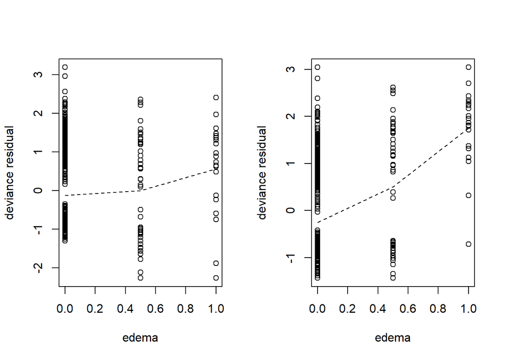

```r
r15 <- resid(fit5,data=pbc,type="deviance")
par(mfrow=c(1,2))
plot(edema,r15,xlab="edema",ylab="deviance residual")
lines(lowess(edema,r15,iter=0),lty=2)
plot(edema,r1,xlab="edema",ylab="deviance residual")
lines(lowess(edema,r1,iter=0),lty=2)
```

```r
par(mfrow=c(1,1))
sum(r15^2) # 516.1889
```

```
## [1] 516.1889
```

#### 변수 edema를 포함한 Cox 모형 적합 후 패턴변화가 줄어듬.

### (6) 공변량이 2개인 비례위험모형을 적합하고 편차 잔차를 구해 잔차그림을 비교해 보시오.

```r
# age, log(bili)
fit <- coxph(Surv(time,censor)~age+log(bili),data=pbc)
summary(fit)
```

```
## Call:
## coxph(formula = Surv(time, censor) ~ age + log(bili), data = pbc)
##
##   n= 418, number of events= 161
##
##               coef exp(coef) se(coef)      z Pr(>|z|)
## age       0.043777  1.044750 0.007504  5.834 5.42e-09 ***
## log(bili) 1.014976  2.759298 0.077961 13.019  < 2e-16 ***
## ---
## Signif. codes:  0 '***' 0.001 '**' 0.01 '*' 0.05 '.' 0.1 ' ' 1
##
##           exp(coef) exp(-coef) lower .95 upper .95
## age           1.045     0.9572     1.029     1.060
## log(bili)     2.759     0.3624     2.368     3.215
##
## Concordance= 0.815  (se = 0.017 )
## Likelihood ratio test= 186.6  on 2 df,   p=<2e-16
## Wald test            = 195.6  on 2 df,   p=<2e-16
## Score (logrank) test = 223.3  on 2 df,   p=<2e-16
```

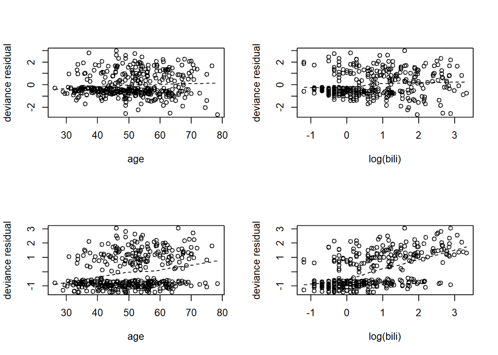

```r
r <- resid(fit,data=pbc,type="deviance")
par(mfrow=c(2,2))
plot(age,r,xlab="age",ylab="deviance residual")
lines(lowess(age,r,iter=0),lty=2)
plot(log(bili),r,xlab="log(bili)",ylab="deviance residual")
lines(lowess(log(bili),r,iter=0),lty=2)
plot(age,r1,xlab="age",ylab="deviance residual")
lines(lowess(age,r1,iter=0),lty=2)
plot(log(bili),r1,xlab="log(bili)",ylab="deviance residual")
lines(lowess(log(bili),r1,iter=0),lty=2)
```

```r
par(mfrow=c(1,1))
```